# Homework W47_A

au668717

2022-11-27

Firstly I create a folder within the Rproj, in which I save the spreadsheet with danish monarchs from Excel as a CSV file:

```r
dir.create("Data")
```

I then attach the tidyverse package with the library function as this includes multiple packages that I will need to solve this task:

```r
library(tidyverse)
```

Next, I ask RStudio to find the spreadsheet of danish monarchs in the Data folder and ask it to read it as a csv2 file (european). I ask for the data to be stored under the name “monarchsReign”, allowing for an easy access-way.

```r
monarchsReign <- read.csv2("Data/monarchs of denmark2.csv")
```

I’m now ready to do a visualization showing the length of reign for each danish monarch I use ggplot and have RStudio reorder the name monarch by their name count (the number in line they ruled as). I have to do this otherwise it will show the monarchs in alphabetical order. The x shows names and the order they ruled in. The y shows how long they ruled for. The visualization is done as a colomn diagram with x and y titles “Monarker” and “Regeringstid”. Lastly I make sure that the names of the monarchs is written in a 90 degree angle to be readable.

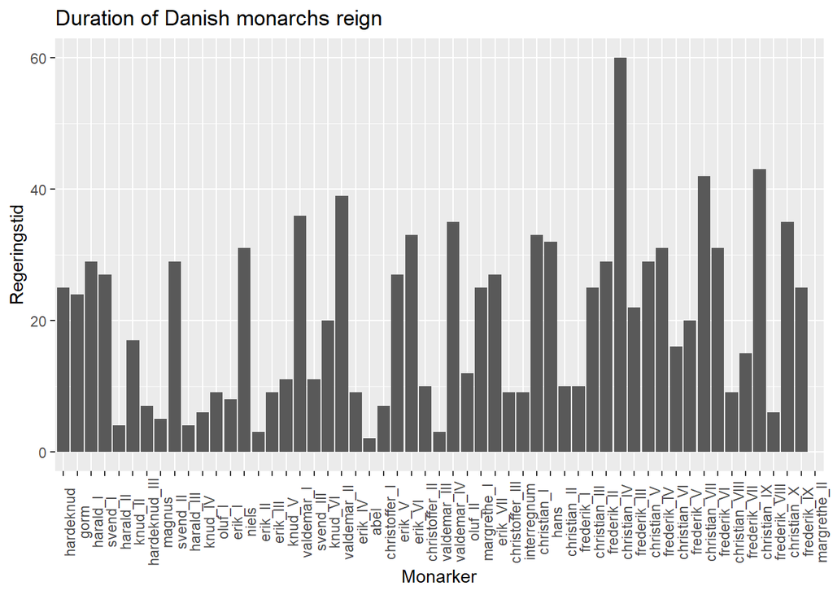

```r
monarchsReign %>%
  select(name_count, name_monarch, reign_length) %>%
  ggplot(aes(x = reorder(name_monarch, name_count), y = reign_length)) +
  geom_col() +
  labs(title = "Duration of Danish monarchs reign") +
  xlab("Monarker") +
  ylab("Regeringstid") +
  theme(axis.text.x = element_text(angle=90))
```